# Respirando hacia la luz: Variación en los estomas de Asterogyne martiana (Arecaceae) en la Estación Biológica La Selva

Kenneth Barrantes, Debora Elías, Miguel Martínez Rodríguez, Nelsy Niño, Fermín L. Felipe & Claudia Segovia.

18/1/2022

Librerias

```r
library(rio)
library(tidyverse)
library(rio)
library(visdat)
library(parameters)
library(performance)
library(see)
library(knitr)
library(DescTools)
library(sjPlot)
library(visreg)
library(bayestestR)
library(effectsize)
library(readr)
library(ggplot2)
```

Cargar base de datos ya transformada en variables numericas y categoricas desde el set de datos

```r
Estomas_base <- read_csv("Estomas.xlsx - Base limpia.csv",
    col_types = cols(altura_hoja = col_number(),
        longitud_hoja = col_number(), Edad = col_factor(levels = c("1",
            "0")), cobertura_dosel = col_number(),
        luz = col_number(), celulas_epidermicas = col_number(),
        largo_estoma = col_number(), ancho_estoma = col_number(),
        densidad_estomatica = col_number(),
        indice_estomatico = col_number(),
        no_estomas = col_number(), pl_estomas = col_number(),
        pa_estomas = col_number(), radio_estoma = col_number(),
        area_estoma = col_number(), area_estoma_m = col_number()))
```

# Modelos

## Modelos con respecto a indice estomatico

Se comparan las variables cobertura de dosel, altura de la hoja y edad con respecto a la variable respuesta indice estomatico

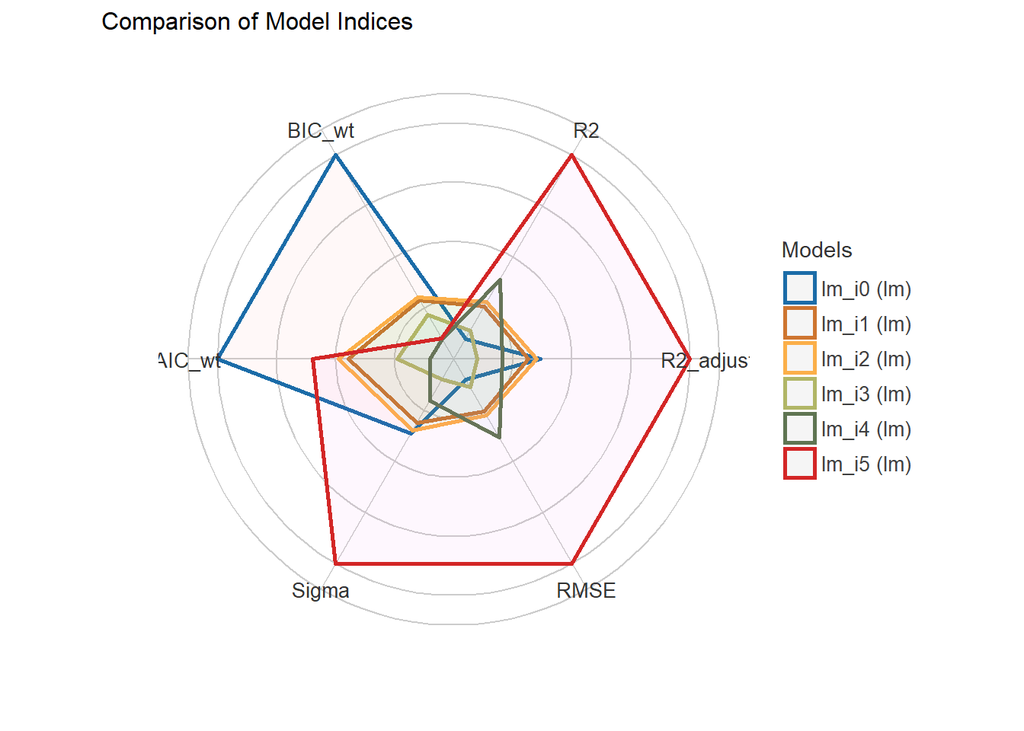

```r
lm_i0 <- lm(indice_estomatico ~ 1, data = Estomas_base)
lm_i1 <- lm(indice_estomatico ~ cobertura_dosel, data = Estomas_base)
lm_i2 <- lm(indice_estomatico ~ altura_hoja, data = Estomas_base)
lm_i3 <- lm(indice_estomatico ~ Edad, data = Estomas_base)
lm_i4 <- lm(indice_estomatico ~ cobertura_dosel + altura_hoja, data = Estomas_base)
lm_i5 <- lm(indice_estomatico ~ cobertura_dosel * altura_hoja, data = Estomas_base)

ci <- compare_performance(lm_i0, lm_i1, lm_i2, lm_i3, lm_i4, lm_i5, rank = TRUE)

plot(ci)
```

```r
ci
```

```
## # Comparison of Model Performance Indices
##
## Name  | Model |    R2 | R2 (adj.) |  RMSE | Sigma | AIC weights | BIC weights | Performance-Score
## -------------------------------------------------------------------------------------------------
## lm_i5 |    lm | 0.136 |     0.055 | 1.319 | 1.399 |       0.193 |       0.035 |            75.91%
## lm_i0 |    lm | 0.000 |     0.000 | 1.418 | 1.438 |       0.280 |       0.543 |            43.22%
## lm_i2 |    lm | 0.027 |    -0.002 | 1.399 | 1.440 |       0.169 |       0.148 |            26.69%
## lm_i1 |    lm | 0.024 |    -0.005 | 1.401 | 1.442 |       0.160 |       0.140 |            23.62%
## lm_i4 |    lm | 0.044 |    -0.014 | 1.387 | 1.449 |       0.085 |       0.034 |            14.46%
## lm_i3 |    lm | 0.006 |    -0.023 | 1.414 | 1.455 |       0.115 |       0.101 |             6.18%
```

El modelo más explicativo es el lm_i5, siendo la cobertura de dosel y la altura de la hoja bajo interacción las que mejor explican el número de estomas por unidad de celulas epiteliales.

```r
cii <- check_normality(lm_i5)
chi <- check_heteroscedasticity(lm_i5)
```

[output not shown]

```
## OK: Error variance appears to be homoscedastic (p = 0.300).
```

```r
cci <- check_collinearity(lm_i5)
```

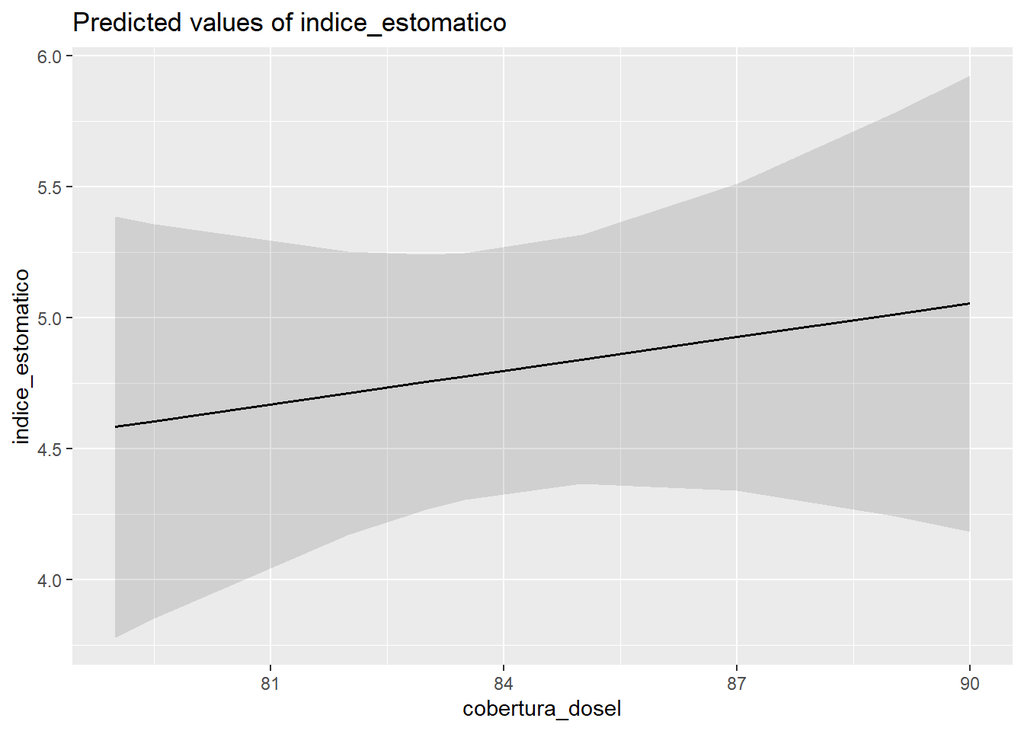

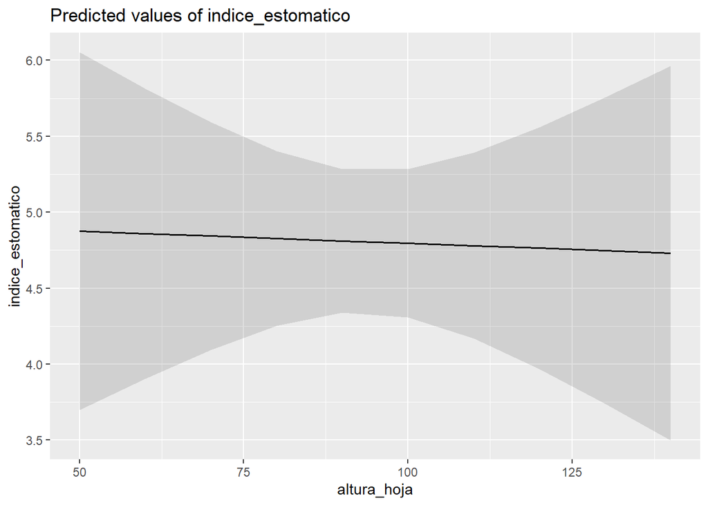

```r
plot_model(lm_i5, type = "pred")
```

```r
summary(lm_i5)
```

```
##
## Call:
## lm(formula = indice_estomatico ~ cobertura_dosel * altura_hoja,
##     data = Estomas_base)
##
## Residuals:
##     Min      1Q  Median      3Q     Max
## -1.8263 -0.9888 -0.0411  0.6688  4.3938
##
## Coefficients:
##                               Estimate Std. Error t value Pr(>|t|)
## (Intercept)                 -45.205175  25.965951  -1.741   0.0913 .
## cobertura_dosel               0.595581   0.302172   1.971   0.0574 .
## altura_hoja                   0.500868   0.277046   1.808   0.0800 .
## cobertura_dosel:altura_hoja  -0.005966   0.003232  -1.846   0.0742 .
## ---
## Signif. codes:  0 '***' 0.001 '**' 0.01 '*' 0.05 '.' 0.1 ' ' 1
##
## Residual standard error: 1.399 on 32 degrees of freedom
## Multiple R-squared:  0.1358, Adjusted R-squared:  0.05473
## F-statistic: 1.676 on 3 and 32 DF,  p-value: 0.1919
```

## Modelo con respecto a densidad estomatica

Se comparan las variables cobertura de dosel, altura de la hoja y edad con respecto a la variable respuesta densidad estomatica

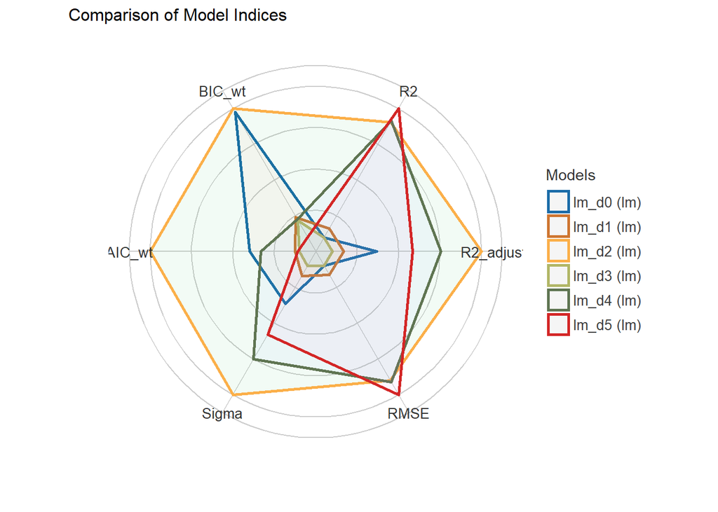

```r
lm_d0 <- lm(densidad_estomatica ~ 1, data = Estomas_base)
lm_d1 <- lm(densidad_estomatica ~ cobertura_dosel, data = Estomas_base)
lm_d2 <- lm(densidad_estomatica ~ altura_hoja, data = Estomas_base)
lm_d3 <- lm(densidad_estomatica ~ Edad, data = Estomas_base)
lm_d4 <- lm(densidad_estomatica ~ cobertura_dosel + altura_hoja, data = Estomas_base)
lm_d5 <- lm(densidad_estomatica ~ cobertura_dosel * altura_hoja, data = Estomas_base)


cd <- compare_performance(lm_d0, lm_d1, lm_d2, lm_d3, lm_d4, lm_d5, rank = TRUE)

plot(cd)
```

```r
cd
```

```
## # Comparison of Model Performance Indices
##
## Name  | Model |        R2 | R2 (adj.) |   RMSE |  Sigma | AIC weights | BIC weights | Performance-Score
## -------------------------------------------------------------------------------------------------------
## lm_d2 |    lm |     0.096 |     0.070 | 17.267 | 17.767 |       0.428 |       0.396 |            96.41%
## lm_d4 |    lm |     0.097 |     0.043 | 17.256 | 18.023 |       0.161 |       0.068 |            60.88%
## lm_d5 |    lm |     0.108 |     0.024 | 17.157 | 18.198 |       0.073 |       0.014 |            51.34%
## lm_d0 |    lm |     0.000 |     0.000 | 18.161 | 18.419 |       0.189 |       0.385 |            31.58%
## lm_d1 |    lm |     0.007 |    -0.022 | 18.094 | 18.618 |       0.079 |       0.073 |             7.89%
## lm_d3 |    lm | 9.357e-22 |    -0.029 | 18.161 | 18.688 |       0.069 |       0.064 |             2.20%
```

El modelo que mejor explica la densidad estomatica es el lm_d2, siendo la altura de la hoja con respecto al suelo la variable que determina el número de estomas por unidad cuadrada

```r
cdi <- check_normality(lm_d2)
chd <- check_heteroscedasticity(lm_d2)
```

[output not shown]

```
## OK: Error variance appears to be homoscedastic (p = 0.799).
```

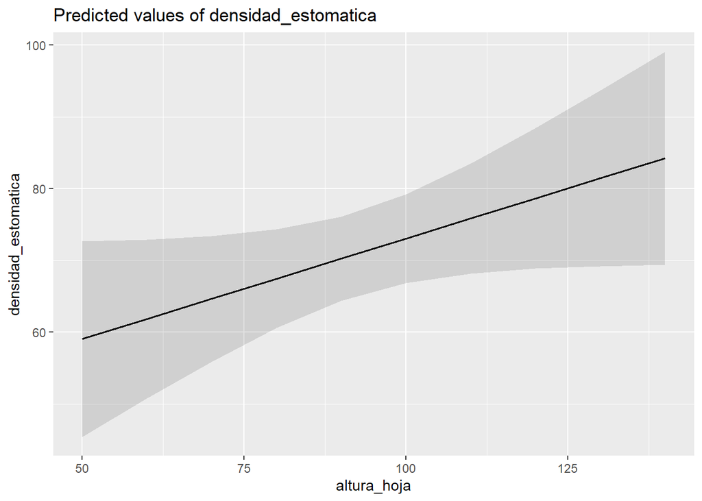

```r
plot_model(lm_d2, type = "pred")
```

```r
summary(lm_d2)
```

```
##
## Call:
## lm(formula = densidad_estomatica ~ altura_hoja, data = Estomas_base)
##
## Residuals:
##     Min      1Q  Median      3Q     Max
## -26.333 -14.615  -0.936  10.222  46.357
##
## Coefficients:
##             Estimate Std. Error t value Pr(>|t|)
## (Intercept)  45.0334    13.9688   3.224  0.00279 **
## altura_hoja   0.2801     0.1473   1.901  0.06577 .
## ---
## Signif. codes:  0 '***' 0.001 '**' 0.01 '*' 0.05 '.' 0.1 ' ' 1
##
## Residual standard error: 17.77 on 34 degrees of freedom
## Multiple R-squared:  0.0961, Adjusted R-squared:  0.06951
## F-statistic: 3.615 on 1 and 34 DF,  p-value: 0.06577
```

## Modelo de área

Se comparan las variables cobertura de dosel, altura de la hoja y edad con respecto a la variable respuesta área del estoma

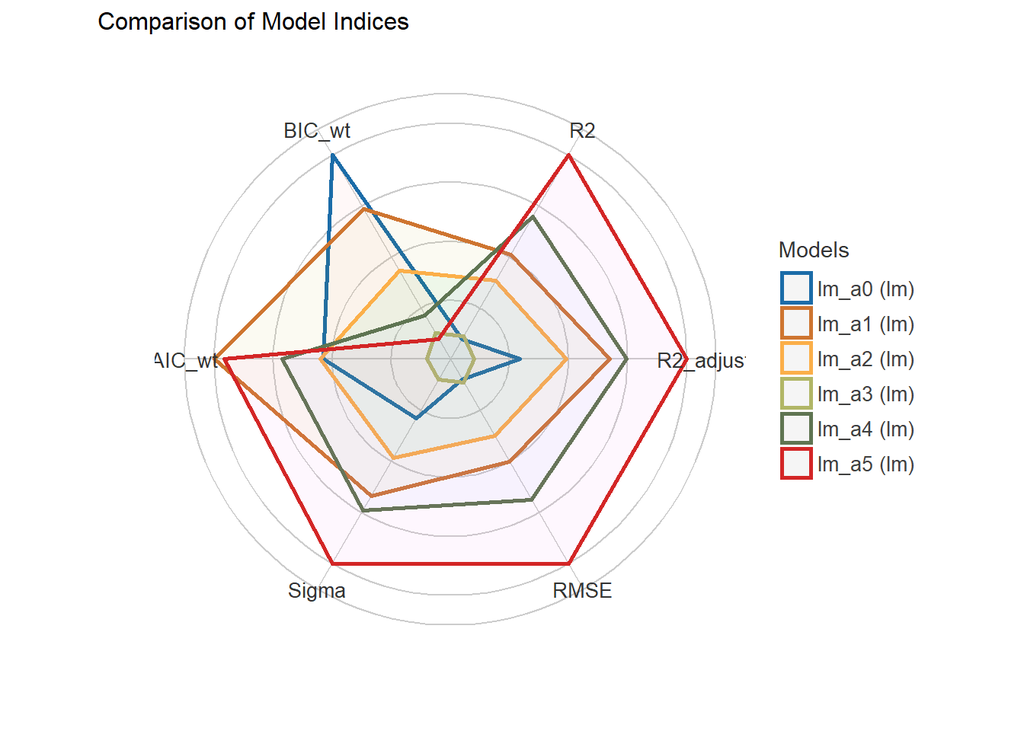

```r
lm_a0 <- lm(area_estoma_m ~ 1, data = Estomas_base)
lm_a1 <- lm(area_estoma_m ~ cobertura_dosel, data = Estomas_base)
lm_a2 <- lm(area_estoma_m ~ altura_hoja, data = Estomas_base)
lm_a3 <- lm(area_estoma_m ~ Edad, data = Estomas_base)
lm_a4 <- lm(area_estoma_m ~ cobertura_dosel + altura_hoja, data = Estomas_base)
lm_a5 <- lm(area_estoma_m ~ cobertura_dosel * altura_hoja, data = Estomas_base)

ca <- compare_performance(lm_a0, lm_a1, lm_a2, lm_a3, lm_a4, lm_a5, rank = TRUE)

plot(ca)
```

```r
ca
```

```
## # Comparison of Model Performance Indices
##
## Name  | Model |    R2 | R2 (adj.) |  RMSE | Sigma | AIC weights | BIC weights | Performance-Score
## -------------------------------------------------------------------------------------------------
## lm_a5 |    lm | 0.175 |     0.098 | 0.093 | 0.099 |       0.231 |       0.053 |            82.54%
## lm_a1 |    lm | 0.080 |     0.053 | 0.098 | 0.101 |       0.240 |       0.268 |            64.70%
## lm_a4 |    lm | 0.116 |     0.063 | 0.096 | 0.100 |       0.181 |       0.092 |            59.12%
## lm_a2 |    lm | 0.055 |     0.027 | 0.099 | 0.102 |       0.148 |       0.166 |            39.19%
## lm_a0 |    lm | 0.000 |     0.000 | 0.102 | 0.104 |       0.145 |       0.358 |            31.81%
## lm_a3 |    lm | 0.003 |    -0.027 | 0.102 | 0.105 |       0.056 |       0.063 |             1.00%
```

El modelo que mejor se ajusta al conjunto de datos es el lm_a5, el cual explica mediante las variables cobertura de dosel y altura de la hoja el area que cubren los estomas

```r
cai <- check_normality(lm_a5)
```

```
## OK: residuals appear as normally distributed (p = 0.669).
```

```r
cha <- check_heteroscedasticity(lm_a5)
```

```
## OK: Error variance appears to be homoscedastic (p = 0.532).
```

```r
cca <- check_collinearity(lm_a5)
```

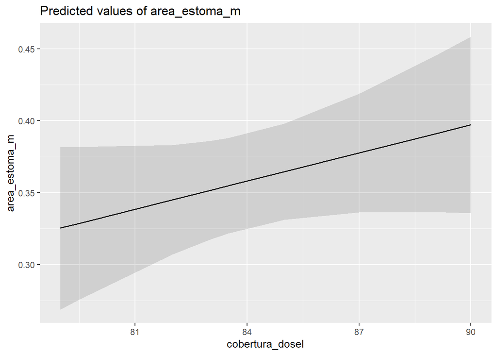

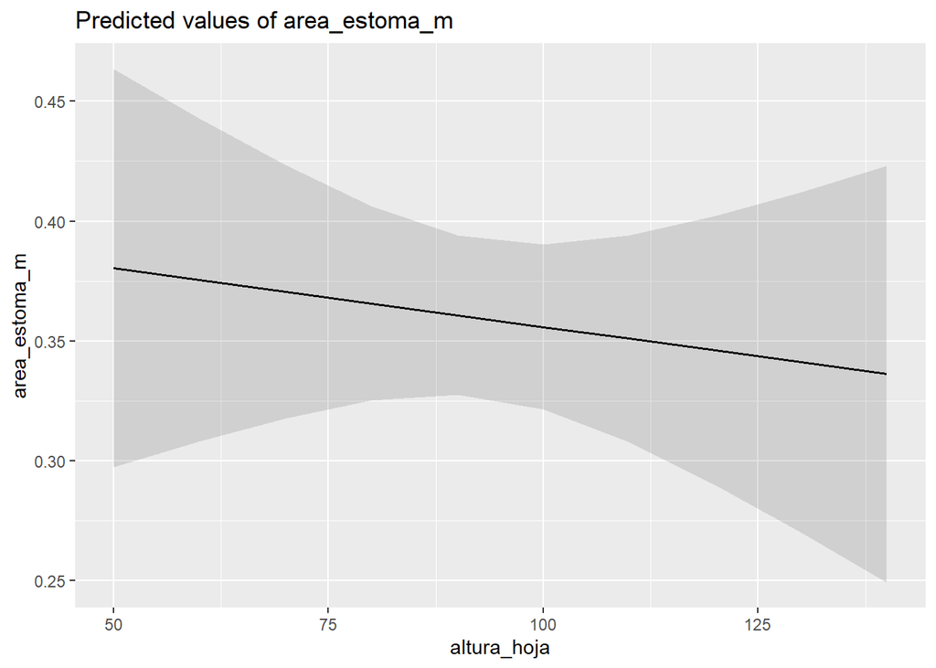

```r
plot_model(lm_a5, type = "pred")
```

```r
summary(lm_a5)
```

```
##
## Call:
## lm(formula = area_estoma_m ~ cobertura_dosel * altura_hoja, data = Estomas_base)
##
## Residuals:
##       Min        1Q    Median        3Q       Max
## -0.233750 -0.044980  0.003353  0.049544  0.217856
##
## Coefficients:
##                               Estimate Std. Error t value Pr(>|t|)
## (Intercept)                 -2.8348319  1.8293580  -1.550   0.1311
## cobertura_dosel              0.0384683  0.0212887   1.807   0.0802 .
## altura_hoja                  0.0285402  0.0195185   1.462   0.1534
## cobertura_dosel:altura_hoja -0.0003447  0.0002277  -1.514   0.1399
## ---
## Signif. codes:  0 '***' 0.001 '**' 0.01 '*' 0.05 '.' 0.1 ' ' 1
##
## Residual standard error: 0.09853 on 32 degrees of freedom
## Multiple R-squared:  0.1752, Adjusted R-squared:  0.09782
## F-statistic: 2.265 on 3 and 32 DF,  p-value: 0.09983
```